# Covid trend analysis according to GDP per capita

Hidetake Takahashi

2021/9/22

### Table of Contents

1. Data
2. Analysis
3. Modeling deaths per million
4. Conclusion and Bias

## Introduction

The purpose of this report is to analyse relationship between covid infection and GDP per capita. Since GDP per capita generally indicates wealthy of country, higher value means well-developed medication (**strong point**) and also higher chance of infection by economical activities (**drawback**).

For analysis, three data is used, global covid cases and deaths, population data from Look-up table, and GDP data from `WDI` library. These data are joined, then correlation between GDP per capita and covid cases/deaths are analysed.

## 1. Data

## 1.1 Libraries

```r
library(tidyverse)
library(lubridate)
library(WDI)
```

### 1.2 Global cases and deaths

Global cases and deaths shows daily cases and deaths in each country since the beginning to today

```r
file_url <- "https://raw.githubusercontent.com/CSSEGISandData/COVID-19/master/csse_covid_19_data/csse_covid_19_time_series/"

file_names <- c("time_series_covid19_confirmed_US.csv",
                "time_series_covid19_confirmed_global.csv",
                "time_series_covid19_deaths_US.csv",
                "time_series_covid19_deaths_global.csv",
                "time_series_covid19_recovered_global.csv")

urls <- str_c(file_url, file_names)

global_cases <- read_csv(urls[2])
global_deaths <- read_csv(urls[4])

global_deaths <- global_deaths %>%
  rename("Province_State" = "Province/State", "country" = "Country/Region")

global_cases <- global_cases %>%
  rename("Province_State" = "Province/State", "country" = "Country/Region")

global_deaths <- global_deaths %>%
  pivot_longer(cols = -c(Province_State:Long), names_to = "date", values_to = "deaths")

global_cases <- global_cases %>%
  pivot_longer(cols = -c(Province_State:Long), names_to = "date", values_to = "cases")

global <- global_cases %>% full_join(global_deaths)
global <- global %>% mutate(date = mdy(date))

global %>% glimpse()
```

```
## Rows: 171,027
## Columns: 7
## $ Province_State <chr> NA, NA, NA, NA, NA, NA, NA, NA, NA, NA, NA, NA, NA, NA,~
## $ country        <chr> "Afghanistan", "Afghanistan", "Afghanistan", "Afghanist~
## $ Lat            <dbl> 33.93911, 33.93911, 33.93911, 33.93911, 33.93911, 33.93~
## $ Long           <dbl> 67.70995, 67.70995, 67.70995, 67.70995, 67.70995, 67.70~
## $ date           <date> 2020-01-22, 2020-01-23, 2020-01-24, 2020-01-25, 2020-0~
## $ cases          <dbl> 0, 0, 0, 0, 0, 0, 0, 0, 0, 0, 0, 0, 0, 0, 0, 0, 0, 0, 0~
## $ deaths         <dbl> 0, 0, 0, 0, 0, 0, 0, 0, 0, 0, 0, 0, 0, 0, 0, 0, 0, 0, 0~
```

### 1.3 Lookup table

Look-up table has Population data of each country. Some countries are divided into main area and separated region and island. Those information is filtered out to prevent mismatch with global cases/deaths data.

```r
uid_lookup_url <- "https://raw.githubusercontent.com/CSSEGISandData/COVID-19/master/csse_covid_19_data/UID_ISO_FIPS_LookUp_Table.csv"
uid <- read_csv(uid_lookup_url)

#Calculate population of each country
uid_iso <- uid %>% dplyr::select(-c(FIPS, Admin2, Province_State)) %>%
  rename("country" = "Country_Region") %>%
  drop_na() %>% group_by(iso2, country) %>% summarise(Population = sum(Population))

# filter out non-main region of country
uid_iso %>%
  filter(!(country == "US" & (iso2 != "US"))) %>%
  filter(!(country == "United Kingdom" & (iso2 != "GB"))) %>%
  filter(!(country == "France" & (iso2 != "FR"))) %>%
  filter(!(country == "Netherlands" & (iso2 != "NL"))) %>%
  filter(!(country == "China" & (iso2 != "CN"))) %>%
  filter(!(country == "Denmark" & (iso2 != "DK")))
```

```
## # A tibble: 193 x 3
## # Groups:   iso2 [193]
##    iso2  country              Population
##    <chr> <chr>                     <dbl>
##  1 AD    Andorra                   77265
##  2 AE    United Arab Emirates    9890400
##  3 AF    Afghanistan            38928341
##  4 AG    Antigua and Barbuda       97928
##  5 AL    Albania                 2877800
##  6 AM    Armenia                 2963234
##  7 AO    Angola                 32866268
##  8 AR    Argentina              45195777
##  9 AT    Austria                 9006400
## 10 AU    Australia              50919400
## # ... with 183 more rows
```

```r
uid_iso %>% glimpse()
```

```
## Rows: 227
## Columns: 3
## Groups: iso2 [227]
## $ iso2       <chr> "AD", "AE", "AF", "AG", "AI", "AL", "AM", "AO", "AR", "AS",~
## $ country    <chr> "Andorra", "United Arab Emirates", "Afghanistan", "Antigua ~
## $ Population <dbl> 77265, 9890400, 38928341, 97928, 15002, 2877800, 2963234, 3~
```

### 1.4 GDP Data

GDP per capita is obtained by **WDI** package. It can be searched by countries’ iso code (iso2 columns of look-up table).

```r
gdp_data = WDI(indicator='NY.GDP.PCAP.KD', country="all", start = 2019, end=2019)
gdp_data <- gdp_data %>% rename("gdpPercap" = "NY.GDP.PCAP.KD" )

gdp_data %>% glimpse()
```

```
## Rows: 266
## Columns: 4
## $ iso2c     <chr> "ZH", "ZI", "1A", "S3", "B8", "V2", "Z4", "4E", "T4", "XC", ~
## $ country   <chr> "Africa Eastern and Southern", "Africa Western and Central",~
## $ gdpPercap <dbl> 1598.3770, 1789.4679, 6484.1185, 9291.2369, 16985.0975, 3757~
## $ year      <int> 2019, 2019, 2019, 2019, 2019, 2019, 2019, 2019, 2019, 2019, ~
```

## 2. Analysis

For this analysis, only the latest data (**total number**) is necessary. Since the number of cases and deaths shows cumulative sum, maximum means total. Those values shall be grouped by country: first, exctract latest vale of each province state and country, then summing-up them by country. Furthermore, mortality rate is calculated by dividing deaths by cases.

```r
global_latest <- global %>% group_by(Province_State, country) %>%
  summarise(lon = mean(Long), lat = mean(Lat), cases = max(cases), deaths =max(deaths))

global_latest <- global_latest %>% group_by(country) %>%
  summarise(lon = mean(lon), lat = mean(lat), cases = sum(cases), deaths = sum(deaths)) %>%
  mutate(mortality_rate = deaths/cases)

global_latest %>% glimpse()
```

```
## Rows: 195
## Columns: 6
## $ country        <chr> "Afghanistan", "Albania", "Algeria", "Andorra", "Angola~
## $ lon            <dbl> 67.709953, 20.168300, 1.659600, 1.521800, 17.873900, -6~
## $ lat            <dbl> 33.93911, 41.15330, 28.03390, 42.50630, -11.20270, 17.0~
## $ cases          <dbl> 154960, 167354, 202574, 15167, 54795, 2902, 5249840, 25~
## $ deaths         <dbl> 7199, 2629, 5767, 130, 1487, 64, 114849, 5239, 1232, 10~
## $ mortality_rate <dbl> 0.046457150, 0.015709215, 0.028468609, 0.008571240, 0.0~
```

```r
uid_iso2 <- uid_iso %>% left_join(global_latest, by = "country")
uid_iso2 <- uid_iso2 %>% left_join(gdp_data, by = c("iso2" = "iso2c"))

uid_iso2 <- uid_iso2 %>%
  mutate(cases_per_mill = cases/Population*10^6,                                          deaths_per_mill =deaths/Population*10^6)

uid_iso2 <- uid_iso2 %>% filter(Population > cases)

uid_iso2 %>% glimpse()
```

```
## Rows: 194
## Columns: 13
## Groups: iso2 [194]
## $ iso2            <chr> "AD", "AE", "AF", "AG", "AL", "AM", "AO", "AR", "AT", ~
## $ country.x       <chr> "Andorra", "United Arab Emirates", "Afghanistan", "Ant~
## $ Population      <dbl> 77265, 9890400, 38928341, 97928, 2877800, 2963234, 328~
## $ lon             <dbl> 1.521800, 53.847818, 67.709953, -61.796400, 20.168300,~
## $ lat             <dbl> 42.50630, 23.42408, 33.93911, 17.06080, 41.15330, 40.0~
## $ cases           <dbl> 15167, 734596, 154960, 2902, 167354, 257620, 54795, 52~
## $ deaths          <dbl> 130, 2089, 7199, 64, 2629, 5239, 1487, 114849, 10961, ~
## $ mortality_rate  <dbl> 0.008571240, 0.002843740, 0.046457150, 0.022053756, 0.~
## $ country.y       <chr> "Andorra", "United Arab Emirates", "Afghanistan", "Ant~
## $ gdpPercap       <dbl> 45959.8483, 41420.4958, 573.2875, 15445.0457, 5207.305~
## $ year            <int> 2019, 2019, 2019, 2019, 2019, 2019, 2019, 2019, 2019, ~
## $ cases_per_mill  <dbl> 196298.4534, 74273.6391, 3980.6474, 29634.0168, 58153.~
## $ deaths_per_mill <dbl> 1682.521193, 211.214915, 184.929535, 653.541377, 913.5~
```

### 2.1 Mortality rate and GDP per capita

Mortality rate of Covid decreases with an increase in GDP per capita. It would imply development of medication contributes recovery from the infection.

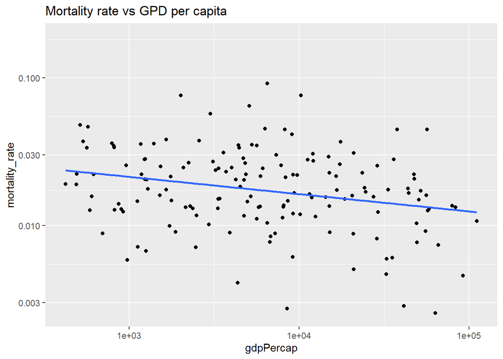

```r
uid_iso2 %>%
  filter(deaths > 100) %>%
  filter(Population > 10^5) %>%
  ggplot(aes(x = gdpPercap, y = mortality_rate)) + geom_point() +
  geom_smooth(method = "lm", se = F) +
  scale_x_log10() +
  scale_y_log10() +
  labs(title = "Mortality rate vs GPD per capita")
```

### 2.2 Cases per million and GDP per capita

According to the below plot, Cases per million increases with GDP per capita. It happends probably because of the larger economical activities in developed countries.

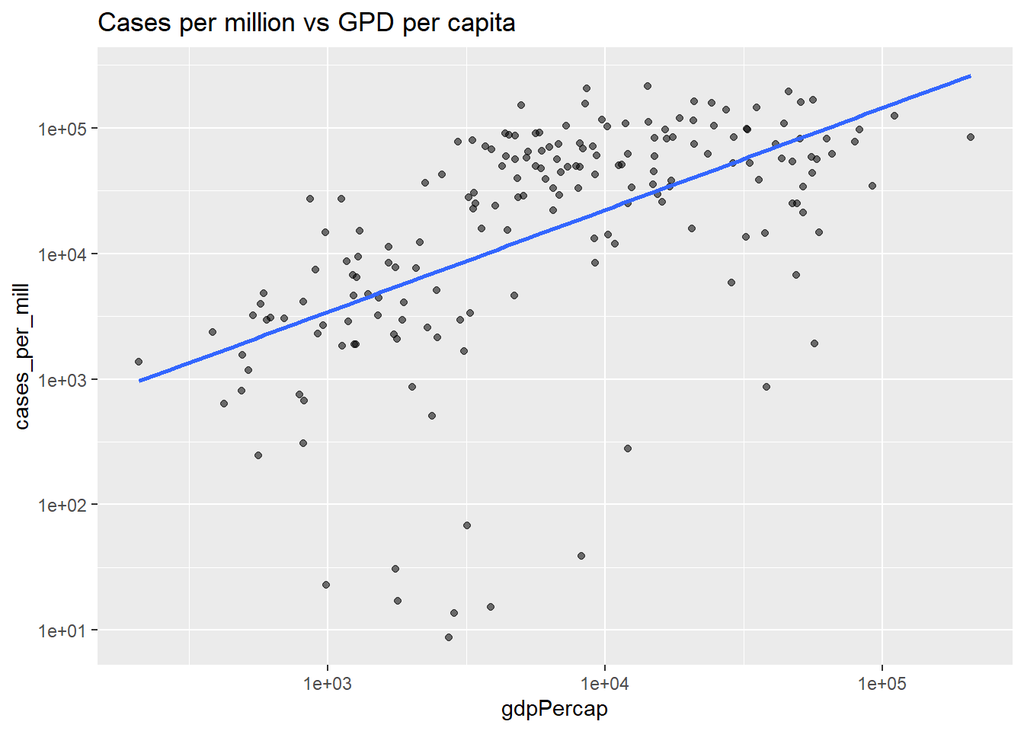

```r
uid_iso2 %>%
  ggplot(aes(x = gdpPercap, y = cases_per_mill, alpha = 0.3))+ geom_point() +
  geom_smooth(method = "lm", se = F) +
  scale_x_log10() +
  scale_y_log10() +
  theme(legend.position = "None") +
  labs(title = "Cases per million vs GPD per capita")
```

### 2.3 Deaths per million and GDP per capita

Following plot shows deaths per million by GDP per capita. Regression line (`geom_smooth`) is not shown, because it is modeled in the chapter 3.

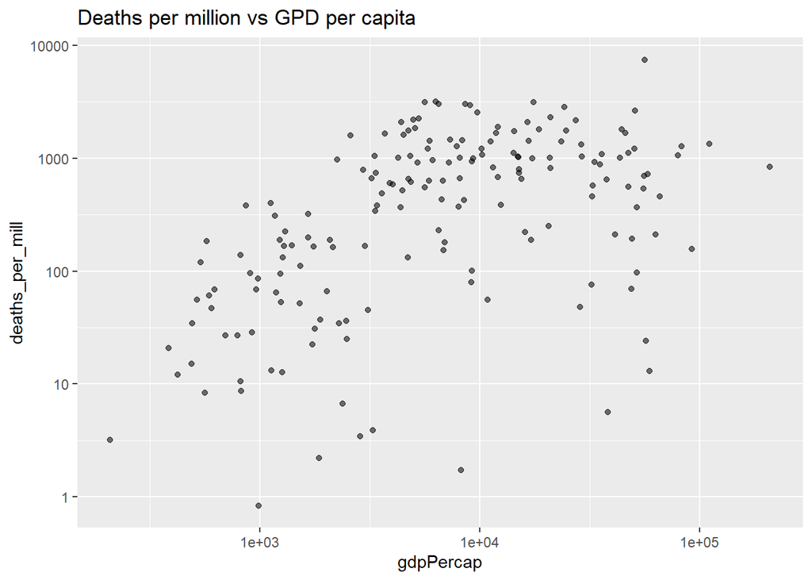

```r
uid_iso2 %>%
  filter(deaths_per_mill > 0) %>%
  ggplot(aes(x = gdpPercap, y = deaths_per_mill, alpha = 0.3))+ geom_point() +
  scale_x_log10() +
  scale_y_log10() +
  theme(legend.position = "None") +
  labs(title = "Deaths per million vs GPD per capita")
```

## 3. Modeling deaths per million

### 3.1 Linear model

```r
data_for_model <- uid_iso2 %>%
  filter(deaths_per_mill > 0)

model_death_lm <- lm(data = data_for_model,
               formula = log10(deaths_per_mill) ~ log10(gdpPercap))
summary(model_death_lm)
```

```
##
## Call:
## lm(formula = log10(deaths_per_mill) ~ log10(gdpPercap), data = data_for_model)
##
## Residuals:
##     Min      1Q  Median      3Q     Max
## -2.2911 -0.3646  0.1279  0.4682  1.0738
##
## Coefficients:
##                  Estimate Std. Error t value Pr(>|t|)
## (Intercept)       0.06999    0.31131   0.225    0.822
## log10(gdpPercap)  0.62810    0.08073   7.781    6e-13 ***
## ---
## Signif. codes:  0 '***' 0.001 '**' 0.01 '*' 0.05 '.' 0.1 ' ' 1
##
## Residual standard error: 0.6815 on 175 degrees of freedom
##   ( 10 個の観測値が欠損のため削除されました )
## Multiple R-squared:  0.257,  Adjusted R-squared:  0.2528
## F-statistic: 60.54 on 1 and 175 DF,  p-value: 6.002e-13
```

```r
pred_lm1 <- predict(object = model_death_lm, data_for_model)
data_for_model$deaths_per_mill_pred_lm <- 10^pred_lm1
```

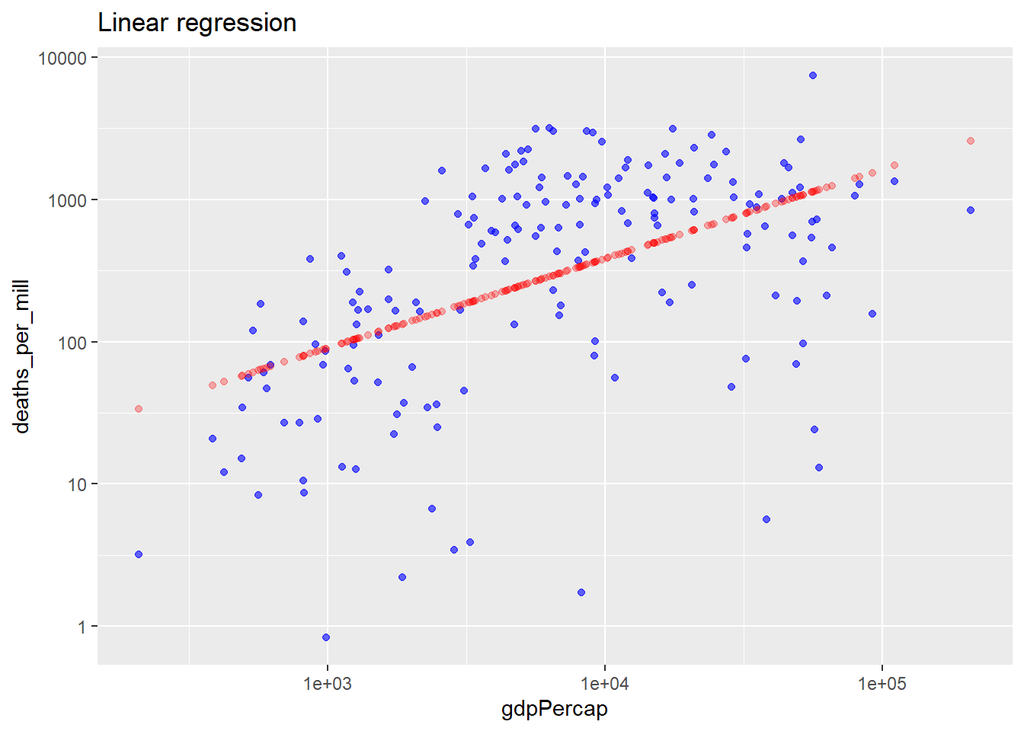

```r
data_for_model %>% ggplot(aes(x=gdpPercap, y = deaths_per_mill)) +
  geom_point(col = "blue", alpha = 0.6) +
  geom_point(aes(y = deaths_per_mill_pred_lm), col = "red", alpha = 0.3) +
  scale_x_log10() + scale_y_log10() +
  labs(title = "Linear regression")
```

### 3.2 Polynomial model

```r
data_for_model <- data_for_model %>%
  mutate(gdpPercap_log10_2 = log10(gdpPercap)^2,
         gdpPercap_log10_3 = log10(gdpPercap)^3 )


model_death_poly <- lm(data = data_for_model,
                formula = log10(deaths_per_mill) ~ gdpPercap_log10_2 + gdpPercap_log10_3)


summary(model_death_poly)
```

```
##
## Call:
## lm(formula = log10(deaths_per_mill) ~ gdpPercap_log10_2 + gdpPercap_log10_3,
##     data = data_for_model)
##
## Residuals:
##     Min      1Q  Median      3Q     Max
## -2.5374 -0.2103  0.1325  0.4018  1.1260
##
## Coefficients:
##                   Estimate Std. Error t value Pr(>|t|)
## (Intercept)       -2.06012    0.55505  -3.712 0.000277 ***
## gdpPercap_log10_2  0.79530    0.11405   6.973 6.18e-11 ***
## gdpPercap_log10_3 -0.12256    0.01939  -6.321 2.12e-09 ***
## ---
## Signif. codes:  0 '***' 0.001 '**' 0.01 '*' 0.05 '.' 0.1 ' ' 1
##
## Residual standard error: 0.6293 on 174 degrees of freedom
##   ( 10 個の観測値が欠損のため削除されました )
## Multiple R-squared:  0.3701, Adjusted R-squared:  0.3629
## F-statistic: 51.12 on 2 and 174 DF,  p-value: < 2.2e-16
```

```r
pred_poly1 <- predict(object = model_death_poly, data_for_model)
data_for_model$deaths_per_mill_pred_poly <- 10^pred_poly1
```

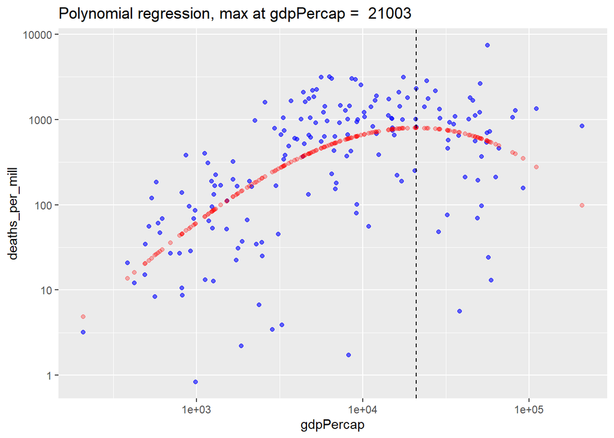

```r
max_value <- data_for_model$deaths_per_mill_pred_poly %>% max(na.rm = TRUE)
max_indx <- which(data_for_model$deaths_per_mill_pred_poly == max_value)
max_gdpPercap <- data_for_model$gdpPercap[max_indx]

data_for_model %>% ggplot(aes(x=gdpPercap, y = deaths_per_mill)) +
  geom_point(col = "blue", alpha = 0.6) +
  geom_point(aes(y = deaths_per_mill_pred_poly), col = "red", alpha = 0.3) +
  scale_x_log10() + scale_y_log10() +
  labs(title = paste("Polynomial regression, max at gdpPercap = ", as.integer(max_gdpPercap))) +
  geom_vline(xintercept = max_gdpPercap, color = "black", linetype = "dashed")
```

### 3.3 Comparing Residuals

Residual of both regression model is plotted in the below figure. Whereas Linear Model has skewed distribution around 10^4, Polynomial Model has more normally distributed accross all GDP per capita.

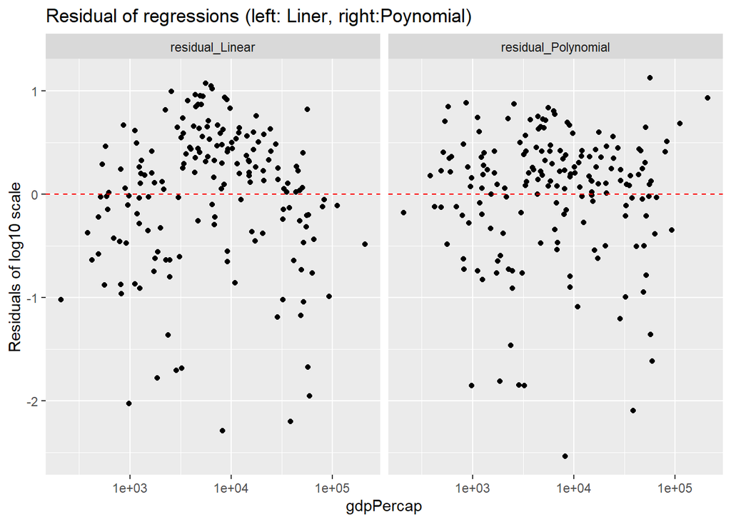

```r
data_for_model %>%
  mutate(residual_Linear = log10(deaths_per_mill) - log10(deaths_per_mill_pred_lm)) %>%
  mutate(residual_Polynomial = log10(deaths_per_mill) - log10(deaths_per_mill_pred_poly)) %>%
  as.data.frame() %>%
  dplyr::select(gdpPercap, residual_Linear, residual_Polynomial) %>%
  gather(key, val, -gdpPercap) %>%
  ggplot(aes(x = gdpPercap, y = val)) + geom_point() +
  facet_wrap(.~key) +
  scale_x_log10() +
  geom_hline(yintercept = 0, linetype = "dashed", color = "red") +
  labs(title = "Residual of regressions (left: Liner, right:Poynomial)") +
  ylab("Residuals of log10 scale")
```

## 4. Conclusion and Bias

**Result**

Mortality rate (death rate) decreases with GDP per capita. It implies medical development. Cases per million increases with GDP per capita, probably because Developed country has higher economical activities and people’s transportation. It leads to larger numbers of infection.

Deaths per million can be predicted based on GDP per capita. Especially, polynomial model did fairly good job. According to regression model, deaths per million has **peak trend at GDP per capita 21000**. It seems that GDP per capita 21000 is the **trade off point** of decreasing Mortality rate(**good effect**) and increasing number of Infection (**adverse effect**).

**Bias**

There would be bias in GDP data. For analysis, Latest covid data is combined with GDP data of 2019. 2019 is selected because 2020 data is not available enough. Therefore, this analysis is based on an assumption that GDP is not changed from 2019 to 2021. However, GDP would be dropped due to the pandemic. This impact is not considered. This type of issues come out sometimes when multiple data from different sources are combined.